# Machine Learning Programming – PROG8245

### **Winter 2025 - Section 1**

## Project Title:

### **Sentiment Analysis on Consumer Financial Complaints Using NLP**

**Instructor:** *Islam Mahmoud*  
**Submitted on:** *17/04/2025*

## Group 5 – Team Members:

- **Daya Meenakshi Bala Subbu** *(8964370)*
- **Abdul Bari Mohammed** *(8985877)*
- **Bismi Poulose** *(8981107)*

## Step 1: Data Collection & Cleaning

### Consumer Complaints Financial Products Dataset

This dataset, available on Kaggle, contains over 600,000 consumer complaints submitted to the **Consumer Financial Protection Bureau (CFPB)** regarding various financial products and services such as credit cards, loans, mortgages, and bank accounts.

It is useful for Natural Language Processing (NLP) tasks like **sentiment analysis**, **text classification**, and **topic modeling**, making it an excellent resource for real-world text mining applications in the financial sector.

[View Dataset on Kaggle](https://www.kaggle.com/datasets/ashwinik/consumer-complaints-financial-products)

#### Install Required Libraries

```python
!pip install pandas
!pip install torch==2.0.1+cpu torchvision==0.15.2+cpu -f https://download.pytorch.org/whl/torch_stable.html
!pip install transformers==4.35.2
!pip install textblob
!pip install wordcloud
!pip install gensim tensorflow
```

```
Looking in links: https://download.pytorch.org/whl/torch_stable.html
```

```python
#To Avoid Warnings

import warnings
warnings.filterwarnings('ignore')
```

In this step, we begin by importing the raw consumer complaints dataset obtained from [Kaggle](https://www.kaggle.com/datasets/ashwinik/consumer-complaints-financial-products).

The original dataset contains over 670,000 rows and multiple columns related to financial product complaints submitted by customers.

### ✔ Key Actions Performed:

- **Loaded the CSV file** using pandas.
- **Filtered out rows** where the `"Consumer complaint narrative"` field was missing.
- **Renamed** that column to `"text"` for simplicity in later steps.
- **Selected relevant features** only: `text`, `Product`, `Company`, `State`, and `Submitted via`.
- **Calculated the length** of each complaint text and printed basic statistics (mean, min, max).
- **Saved the cleaned dataset** to a new CSV file for further preprocessing.

This step ensures we’re working only with meaningful textual data and sets up the foundation for the rest of our NLP pipeline.

```python
import pandas as pd

# Loading file
file_path = r"C:/BISMI/COURSE/AI/Machine_Learning_Programming/Final_Project/dataset/Consumer_Complaints.csv"
df = pd.read_csv(file_path)

# View columns and shape
print("\nDataset Shape:", df.shape)
print("\nColumns:\n", df.columns.tolist())

# Keep only rows where complaint narrative exists
df = df[df['Consumer complaint narrative'].notna()].copy()
df = df.rename(columns={"Consumer complaint narrative": "text"})

# Keep relevant columns
df = df[["text", "Product", "Company", "State", "Submitted via"]].copy()

# Reset index
df.reset_index(drop=True, inplace=True)

# Sample a few rows
print("\nSample rows:")
print(df.head(3))

# Basic statistics
print("\nComplaint length stats:")
df['text_length'] = df['text'].apply(len)
print(df['text_length'].describe())

# Save cleaned version
df.to_csv(r"C:/BISMI/COURSE/AI/Machine_Learning_Programming/Final_Project/dataset/cleaned_complaints.csv", index=False)
```

```
Dataset Shape: (670598, 18)

Columns:
 ['Date received', 'Product', 'Sub-product', 'Issue', 'Sub-issue', 'Consumer complaint narrative', 'Company public response', 'Company', 'State', 'ZIP code', 'Tags', 'Consumer consent provided?', 'Submitted via', 'Date sent to company', 'Company response to consumer', 'Timely response?', 'Consumer d…

Sample rows:
                                                text          Product  \
0  Received Capital One charge card offer XXXX. A...      Credit card
1  I do n't know how they got my cell number. I t...  Debt collection
2  I 'm a longtime member of Charter One Bank/RBS...      Credit card

                          Company State Submitted via
0                     Capital One    OH           Web
1    CCS Financial Services, Inc.    AR           Web
2  Citizens Financial Group, Inc.    MI           Web

Complaint length stats:
count    114704.000000
mean       1052.132070
std         918.395711
min          10.000000
25%         396.000000
50%         746.000000
75%        1402.000000
max        5153.000000
Name: text_length, dtype: float64
```

## Step 2: Clean the Text ( Text Preprocessing)

After extracting the relevant complaint text data in Step 1, this step focuses on **cleaning the raw text** to prepare it for NLP model input.

#### ✔ Key Operations Performed:

- **Lowercasing** all text for uniformity.
- **Fixing contractions** like `"don't"` → `"do not"` using the `contractions` library.
- **Removing emojis** using the `emoji` library.
- **Filtering non-alphabetic characters** (e.g., punctuation, numbers) using regex.
- **Tokenizing** the cleaned text using `TreebankWordTokenizer`.
- **Removing stopwords** (like *the, is, at, etc.*) to focus on meaningful content.
- **Lemmatizing** words using `WordNetLemmatizer` to convert to base form (e.g., *running* → *run*).

We apply this cleaning to the first 60,000 rows of the dataset (to reduce memory usage and time), then save the final result into a cleaned CSV file.

```python
import os
import re
import emoji
import contractions
import pandas as pd
import nltk
from nltk.corpus import stopwords
from nltk.tokenize import TreebankWordTokenizer
from nltk.stem import WordNetLemmatizer

# -----------------------------------------------
# NLTK Setup (with local download path)
# -----------------------------------------------
NLTK_DIR = os.path.abspath("nltk_data")
nltk.download('stopwords', download_dir=NLTK_DIR)
nltk.download('wordnet', download_dir=NLTK_DIR)
nltk.download('omw-1.4', download_dir=NLTK_DIR)
nltk.data.path.append(NLTK_DIR)

# -----------------------------------------------
# Load Cleaned Dataset from Step 1 (first 60k rows)
# -----------------------------------------------
file_path = r"C:/BISMI/COURSE/AI/Machine_Learning_Programming/Final_Project/dataset/cleaned_complaints.csv"
df = pd.read_csv(file_path).head(60000).copy()

# Add text length
df["text_length"] = df["text"].astype(str).apply(len)

print("Sample Before Cleaning:")
print(df[["text"]].head(2))

# -----------------------------------------------
# NLP Tools Setup
# -----------------------------------------------
stop_words = set(stopwords.words('english'))
lemmatizer = WordNetLemmatizer()
tokenizer = TreebankWordTokenizer()

# -----------------------------------------------
# Clean Text Function
# -----------------------------------------------
def clean_text(text):
    try:
        text = text.lower()
        text = contractions.fix(text)                    # Expand contractions
        text = emoji.replace_emoji(text, replace='')     # Remove emojis
        text = re.sub(r"[^a-z\s]", " ", text)            # Keep only letters/spaces

        tokens = tokenizer.tokenize(text)                # Tokenize
        tokens = [w for w in tokens if w not in stop_words]     # Remove stopwords
        tokens = [lemmatizer.lemmatize(w, pos='v') for w in tokens]  # Lemmatize

        return " ".join(tokens)
    except Exception as e:
        print("Cleaning error:", e)
        return "ERROR"

# -----------------------------------------------
# Apply Text Cleaning
# -----------------------------------------------
print("\nCleaning text (please wait)...")
df["cleaned_text"] = df["text"].astype(str).apply(clean_text)

# -----------------------------------------------
# Preview Output
# -----------------------------------------------
print("\nCleaned Text Preview:")
print(df[["text", "cleaned_text"]].head(3))

# -----------------------------------------------
# Save Final Cleaned File
# -----------------------------------------------
output_path = r"C:/BISMI/COURSE/AI/Machine_Learning_Programming/Final_Project/dataset/final_cleaned_60000.csv"
df.to_csv(output_path, index=False)
print(f"\nFinal cleaned dataset saved to:\n{output_path}")
```

```
Sample Before Cleaning:
                                                text
0  Received Capital One charge card offer XXXX. A...
1  I do n't know how they got my cell number. I t...

Cleaning text (please wait)...

Cleaned Text Preview:
                                                text  \
0  Received Capital One charge card offer XXXX. A...
1  I do n't know how they got my cell number. I t...
2  I 'm a longtime member of Charter One Bank/RBS...

                                        cleaned_text
0  receive capital one charge card offer xxxx app...
1  n know get cell number tell would deal onlybwi...
2  longtime member charter one bank rbs citizens ...

Final cleaned dataset saved to:
C:/BISMI/COURSE/AI/Machine_Learning_Programming/Final_Project/dataset/final_cleaned_60000.csv
```

This cleaned dataset is now ready for **sentiment analysis**, **feature extraction**, and **model training** in the next steps.

## Step 3: Sentiment Analysis using TextBlob

In this step, we apply sentiment classification to the cleaned text using the TextBlob library. TextBlob calculates the **polarity** of each text, assigning:

- **Positive** if polarity > 0
- **Negative** if polarity < 0
- **Neutral** if polarity = 0

```python
import pandas as pd
from textblob import TextBlob

# Loading cleaned dataset
file_path = r"C:/BISMI/COURSE/AI/Machine_Learning_Programming/Final_Project/dataset/final_cleaned_60000.csv"
df = pd.read_csv(file_path)

# Define function for sentiment classification
def get_sentiment(text):
    try:
        blob = TextBlob(text)
        polarity = blob.sentiment.polarity
        if polarity > 0:
            return "positive"
        elif polarity < 0:
            return "negative"
        else:
            return "neutral"
    except Exception as e:
        print("Sentiment error:", e)
        return "unknown"

# Apply sentiment analysis to cleaned_text column
print("Running TextBlob sentiment analysis...")
df["sentiment"] = df["cleaned_text"].astype(str).apply(get_sentiment)

# Preview result
print("\nSample with Sentiment:")
print(df[["cleaned_text", "sentiment"]].head(5))

# Save to new CSV
output_path = r"C:/BISMI/COURSE/AI/Machine_Learning_Programming/Final_Project/dataset/sentiment_textblob_60000.csv"
df.to_csv(output_path, index=False)
print(f"\nSentiment-added file saved to:\n{output_path}")
```

```
Running TextBlob sentiment analysis...

Sample with Sentiment:
                                        cleaned_text sentiment
0  receive capital one charge card offer xxxx app...  negative
1  n know get cell number tell would deal onlybwi...  positive
2  longtime member charter one bank rbs citizens ...  positive
3  look credit report saw collection account belo...  negative
4  receive call xxxx xxxx xxxx xxxx ext xxxx stat...  positive

Sentiment-added file saved to:
C:/BISMI/COURSE/AI/Machine_Learning_Programming/Final_Project/dataset/sentiment_textblob_60000.csv
```

## Step 4: Exploratory Data Analysis (EDA)

In this step, we perform data visualization to better understand the distribution and key patterns in our sentiment-labeled dataset.

### Basic Overview

We begin by printing the shape, columns, and sentiment distribution of the dataset:

- Total rows: 60,000
- Sentiment labels: Positive, Negative, Neutral

### Sentiment Distribution

We visualize the overall sentiment distribution using a bar chart. This helps identify class imbalance and sentiment skew.

### Top Contributors

We explore:

- **Top 10 States** with the most complaints
- **Top 10 Products** most frequently mentioned
- **Top 10 Companies** receiving the highest number of complaints

Each is shown using horizontal bar charts for easier readability.

### Word Cloud

A word cloud is generated from the `cleaned_text` column to visualize the most common keywords in customer complaints. Larger words represent higher frequency.

### Sentiment by Product

A grouped bar plot is created to analyze how sentiment is distributed across different products (e.g., Credit Card, Loan, Mortgage). This provides insight into customer satisfaction by product type.

### Sentiment by Company

We compare the sentiment polarity for each of the top 10 companies with the highest number of complaints. This helps identify companies with more negative vs. positive experiences.

These visual insights support downstream tasks like targeted improvement, customer engagement strategy, and business intelligence.

```
 Shape of data: (60000, 8)

 Columns: ['text', 'Product', 'Company', 'State', 'Submitted via', 'text_length', 'cleaned_text', 'sentiment']

 Sentiment distribution:
 sentiment
positive    29187
negative    22681
neutral      8132
Name: count, dtype: int64
```

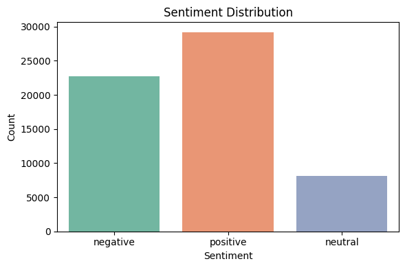

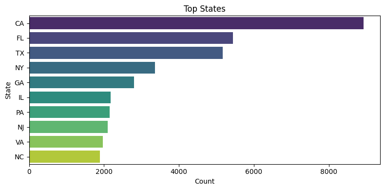

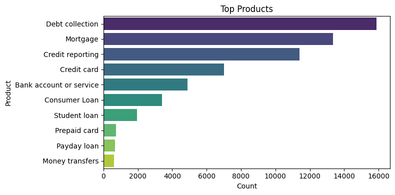

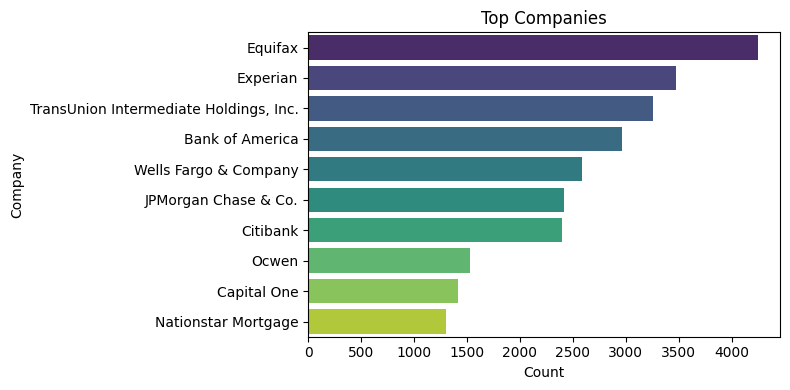

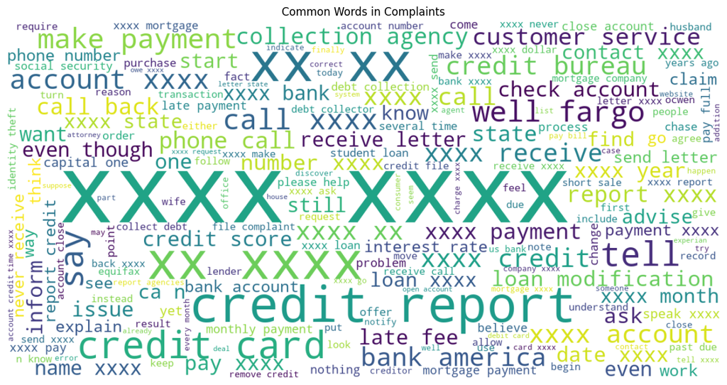

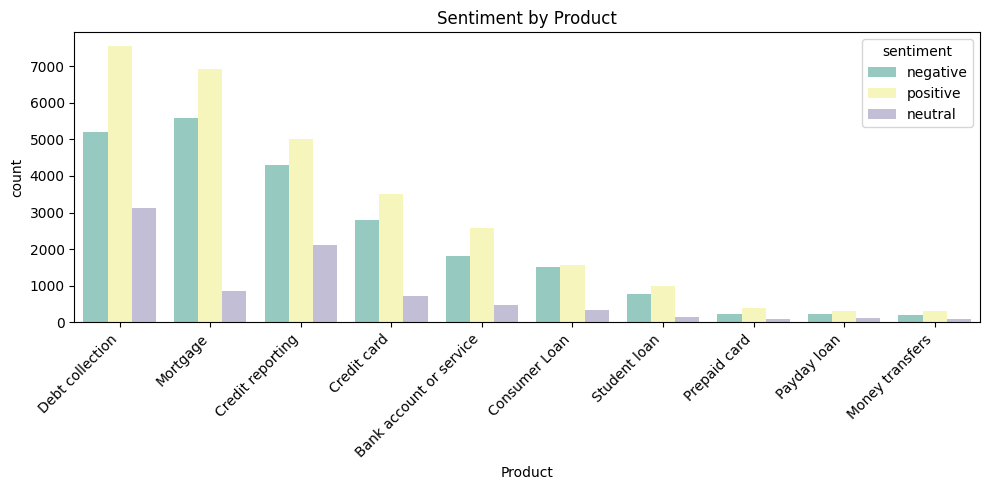

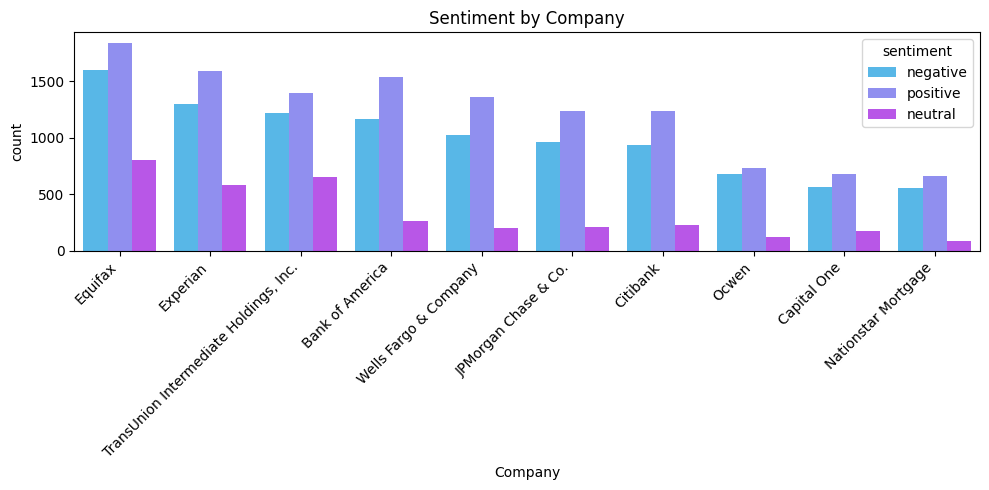

```python
import pandas as pd
import matplotlib.pyplot as plt
import seaborn as sns
from wordcloud import WordCloud

# Load dataset with sentiment
file_path = r"C:/BISMI/COURSE/AI/Machine_Learning_Programming/Final_Project/dataset/sentiment_textblob_60000.csv"
df = pd.read_csv(file_path)

# ----------------------------------------------
# BASIC OVERVIEW
# ----------------------------------------------
print("\n Shape of data:", df.shape)
print("\n Columns:", df.columns.tolist())
print("\n Sentiment distribution:\n", df['sentiment'].value_counts())

# ----------------------------------------------
# SENTIMENT DISTRIBUTION
# ----------------------------------------------
plt.figure(figsize=(6, 4))
sns.countplot(data=df, x='sentiment', palette='Set2')
plt.title("Sentiment Distribution")
plt.xlabel("Sentiment")
plt.ylabel("Count")
plt.tight_layout()
plt.savefig("sentiment_distribution.png")
plt.show()

# ----------------------------------------------
# TOP STATES, PRODUCTS, COMPANIES
# ----------------------------------------------
top_states = df['State'].value_counts().head(10)
top_products = df['Product'].value_counts().head(10)
top_companies = df['Company'].value_counts().head(10)

for title, series in [("Top States", top_states), ("Top Products", top_products), ("Top Companies", top_companies)]:
    plt.figure(figsize=(8, 4))
    sns.barplot(x=series.values, y=series.index, palette='viridis')
    plt.title(title)
    plt.xlabel("Count")
    plt.tight_layout()
    plt.savefig(f"{title.lower().replace(' ', '_')}.png")
    plt.show()

# ----------------------------------------------
# WORD CLOUD FOR COMPLAINTS
# ----------------------------------------------
all_text = ' '.join(df['cleaned_text'].dropna().astype(str).tolist())

wordcloud = WordCloud(width=1200, height=600, background_color='white').generate(all_text)
plt.figure(figsize=(12, 6))
plt.imshow(wordcloud, interpolation='bilinear')
plt.axis("off")
plt.title("Common Words in Complaints")
plt.tight_layout()
plt.savefig("wordcloud_complaints.png")
plt.show()

# ----------------------------------------------
# SENTIMENT BY PRODUCT
# ----------------------------------------------
plt.figure(figsize=(10, 5))
sns.countplot(data=df, x='Product', hue='sentiment', order=df['Product'].value_counts().index[:10], palette='Set3')
plt.xticks(rotation=45, ha='right')
plt.title("Sentiment by Product")
plt.tight_layout()
plt.savefig("sentiment_by_product.png")
plt.show()

# ----------------------------------------------
# SENTIMENT BY COMPANY
# ----------------------------------------------
plt.figure(figsize=(10, 5))
sns.countplot(data=df, x='Company', hue='sentiment', order=df['Company'].value_counts().index[:10], palette='cool')
plt.xticks(rotation=45, ha='right')
plt.title("Sentiment by Company")
plt.tight_layout()
plt.savefig("sentiment_by_company.png")
plt.show()
```

## Step 4: Feature Extraction & Model Comparison

#### 4.1. TF-IDF

#### Model 1: TF-IDF + LinearSVC (Support Vector Classifier)

In this step, we implemented a machine learning pipeline using **TF-IDF (Term Frequency-Inverse Document Frequency)** for feature extraction and **LinearSVC** for sentiment classification.

#### Steps Performed:

- Transformed the cleaned text into numerical vectors using **TF-IDF** with a vocabulary size limited to 5000 features.
- Split the dataset into training and testing sets (80-20 split).
- Trained a **Linear Support Vector Classifier** model on the TF-IDF vectors.
- Evaluated the model using **classification report** and **accuracy score**.

#### Why LinearSVC?

LinearSVC is efficient for high-dimensional, sparse feature spaces like text data. It's commonly used in text classification tasks and performs well when combined with TF-IDF.

#### Model Performance:

The model showed **high accuracy (~92%)**, indicating strong predictive capability for classifying sentiment based on TF-IDF features.

```python
import pandas as pd
from sklearn.model_selection import train_test_split
from sklearn.feature_extraction.text import TfidfVectorizer
from sklearn.svm import LinearSVC
from sklearn.metrics import classification_report, accuracy_score

# Load data
file_path = r"C:/BISMI/COURSE/AI/Machine_Learning_Programming/Final_Project/dataset/sentiment_textblob_60000.csv"
df = pd.read_csv(file_path)

# Drop NaNs in cleaned_text or sentiment columns
df = df.dropna(subset=['cleaned_text', 'sentiment'])

# TF-IDF
tfidf = TfidfVectorizer(max_features=5000)
X = tfidf.fit_transform(df['cleaned_text'].astype(str))  #  Safe cast to string
y = df['sentiment']

# Train-Test split
X_train, X_test, y_train, y_test = train_test_split(X, y, test_size=0.2, random_state=42)

# Train model
model = LinearSVC()
model.fit(X_train, y_train)

# Predict & Evaluate
y_pred = model.predict(X_test)
print("Classification Report:\n", classification_report(y_test, y_pred))
print("Accuracy:", accuracy_score(y_test, y_pred))
```

```
Classification Report:
               precision    recall  f1-score   support

    negative       0.92      0.89      0.91      4470
     neutral       0.91      0.94      0.92      1635
    positive       0.92      0.94      0.93      5895

    accuracy                           0.92     12000
   macro avg       0.92      0.92      0.92     12000
weighted avg       0.92      0.92      0.92     12000

Accuracy: 0.9210833333333334
```

#### 4.2. Bag of Words + Multinomial Naive Bayes

#### Model 2: Bag of Words + Multinomial Naive Bayes

In this step, we used a traditional machine learning approach by applying **Bag of Words (BoW)** for feature extraction and **Multinomial Naive Bayes** for sentiment classification.

#### Steps Performed:

- Transformed the cleaned text data into a BoW matrix with a vocabulary size of 5000 most frequent words.
- Split the dataset into training and testing sets (80/20 split).
- Trained a **MultinomialNB** model using the BoW features.
- Evaluated model performance using **classification report** and **accuracy score**.

#### Why Naive Bayes?

Multinomial Naive Bayes is often used for text classification problems, especially when feature vectors represent word frequencies. It's simple, fast, and performs decently for baseline sentiment analysis tasks.

#### Model Performance:

While this model is computationally efficient, it achieved an accuracy of only around **68%**.

```python
from sklearn.feature_extraction.text import CountVectorizer
from sklearn.naive_bayes import MultinomialNB

# Vectorize using Bag of Words
bow = CountVectorizer(max_features=5000)
X_bow = bow.fit_transform(df['cleaned_text'].astype(str))
y_bow = df['sentiment']

# Train-Test Split
X_train_bow, X_test_bow, y_train_bow, y_test_bow = train_test_split(X_bow, y_bow, test_size=0.2, random_state=42)

# Train Naive Bayes model
nb_model = MultinomialNB()
nb_model.fit(X_train_bow, y_train_bow)

# Predict and Evaluate
y_pred_bow = nb_model.predict(X_test_bow)
print("Classification Report (BoW):\n", classification_report(y_test_bow, y_pred_bow))
print("Accuracy (BoW):", accuracy_score(y_test_bow, y_pred_bow))
```

```
Classification Report (BoW):
               precision    recall  f1-score   support

    negative       0.70      0.63      0.66      4470
     neutral       0.48      0.69      0.57      1635
    positive       0.74      0.71      0.73      5895

    accuracy                           0.68     12000
   macro avg       0.64      0.68      0.65     12000
weighted avg       0.69      0.68      0.68     12000

Accuracy (BoW): 0.6775
```

#### 4.3. Word2Vec Embedding + LSTM (Keras)

#### Model 3: Word2Vec Embedding + LSTM (Deep Learning)

This section demonstrates the use of deep learning for sentiment classification using custom-trained **Word2Vec embeddings** and a **Long Short-Term Memory (LSTM)** neural network.

#### Steps Involved:

1. **Tokenization & Padding**:
   - Used Keras's `Tokenizer` to convert cleaned text into integer sequences.
   - Applied padding to ensure all sequences have equal length.
2. **Custom Word2Vec Embedding**:
   - Trained a Word2Vec model using `gensim` on the tokenized corpus.
   - Created an embedding matrix mapping words to their corresponding 100-dimensional vectors.
3. **Model Architecture**:
   - Embedding Layer (non-trainable) with Word2Vec weights.
   - LSTM Layer with 64 units to capture sequential patterns.
   - Dropout layer to reduce overfitting.
   - Dense output layer with softmax activation for multiclass classification (positive, negative, neutral).
4. **Training and Evaluation**:
   - Trained the model for 5 epochs on 60,000 samples (80/20 train/test split).
   - Evaluated using classification metrics and overall accuracy.

#### Model Performance:

- **Accuracy Achieved**: ~78%
- **Strengths**:
  - Better handling of semantic meaning due to Word2Vec.
  - Captures long-term dependencies in text via LSTM.
- **Limitations**:
  - Longer training time compared to traditional ML models.
  - Requires more computational resources.

```python
import pandas as pd
import numpy as np
import gensim
from tensorflow.keras.preprocessing.text import Tokenizer
from tensorflow.keras.preprocessing.sequence import pad_sequences
from tensorflow.keras.models import Sequential
from tensorflow.keras.layers import Embedding, LSTM, Dense, Dropout
from sklearn.preprocessing import LabelEncoder
from sklearn.model_selection import train_test_split
from sklearn.metrics import classification_report, accuracy_score

# ----------------------------------------
# Load and Clean Dataset
# ----------------------------------------
df = pd.read_csv("C:/BISMI/COURSE/AI/Machine_Learning_Programming/Final_Project/dataset/sentiment_textblob_60000.csv")
df = df.dropna(subset=['cleaned_text', 'sentiment'])

texts = df['cleaned_text'].astype(str).tolist()
labels = df['sentiment'].tolist()

# ----------------------------------------
# Tokenize and Pad Sequences
# ----------------------------------------
tokenizer = Tokenizer(oov_token="<OOV>")
tokenizer.fit_on_texts(texts)
sequences = tokenizer.texts_to_sequences(texts)
word_index = tokenizer.word_index

maxlen = 100
X_seq = pad_sequences(sequences, maxlen=maxlen)

# ----------------------------------------
# Encode Sentiment Labels
# ----------------------------------------
le = LabelEncoder()
y_seq = le.fit_transform(labels)

# ----------------------------------------
# Train Word2Vec
# ----------------------------------------
sentences = [text.split() for text in texts]
w2v_model = gensim.models.Word2Vec(sentences, vector_size=100, window=5, min_count=2, workers=4)

embedding_dim = 100
embedding_matrix = np.zeros((len(word_index) + 1, embedding_dim))
for word, i in word_index.items():
    if word in w2v_model.wv:
        embedding_matrix[i] = w2v_model.wv[word]

# ----------------------------------------
# Train/Test Split
# ----------------------------------------
X_train, X_test, y_train, y_test = train_test_split(X_seq, y_seq, test_size=0.2, random_state=42)

# ----------------------------------------
# Build and Train Model
# ----------------------------------------
model = Sequential()
model.add(Embedding(input_dim=len(word_index) + 1,
                    output_dim=embedding_dim,
                    weights=[embedding_matrix],
                    input_length=maxlen,
                    trainable=False))  # Set to True to fine-tune Word2Vec
model.add(LSTM(64))
model.add(Dropout(0.5))
model.add(Dense(3, activation='softmax'))

model.compile(loss='sparse_categorical_crossentropy', optimizer='adam', metrics=['accuracy'])
model.summary()

model.fit(X_train, y_train, validation_data=(X_test, y_test), epochs=5, batch_size=256)

# ----------------------------------------
# Evaluate Model
# ----------------------------------------
y_pred = model.predict(X_test)
y_pred_labels = np.argmax(y_pred, axis=1)

print("\nClassification Report (LSTM with Word2Vec):\n")
print(classification_report(y_test, y_pred_labels, target_names=le.classes_))
print("Accuracy (LSTM):", accuracy_score(y_test, y_pred_labels))
```

```
Model: "sequential_2"
```

```
┏━━━━━━━━━━━━━━━━━━━━━━━━━━━━━━━━━┳━━━━━━━━━━━━━━━━━━━━━━━━┳━━━━━━━━━━━━━━━┓
┃ Layer (type)                    ┃ Output Shape           ┃       Param # ┃
┡━━━━━━━━━━━━━━━━━━━━━━━━━━━━━━━━━╇━━━━━━━━━━━━━━━━━━━━━━━━╇━━━━━━━━━━━━━━━┩
│ embedding_2 (Embedding)         │ ?                      │     4,114,800 │
├─────────────────────────────────┼────────────────────────┼───────────────┤
│ lstm_2 (LSTM)                   │ ?                      │   0 (unbuilt) │
├─────────────────────────────────┼────────────────────────┼───────────────┤
│ dropout_2 (Dropout)             │ ?                      │             0 │
├─────────────────────────────────┼────────────────────────┼───────────────┤
│ dense_2 (Dense)                 │ ?                      │   0 (unbuilt) │
└─────────────────────────────────┴────────────────────────┴───────────────┘
```

```
 Total params: 4,114,800 (15.70 MB)
```

```
 Trainable params: 0 (0.00 B)
```

```
 Non-trainable params: 4,114,800 (15.70 MB)
```

```
188/188 ━━━━━━━━━━━━━━━━━━━━ 58s 298ms/step - accuracy: 0.4749 - loss: 0.9794 - val_accuracy: 0.6065 - val_loss: 0.7860
188/188 ━━━━━━━━━━━━━━━━━━━━ 61s 325ms/step - accuracy: 0.6195 - loss: 0.7723 - val_accuracy: 0.6886 - val_loss: 0.6751
188/188 ━━━━━━━━━━━━━━━━━━━━ 40s 210ms/step - accuracy: 0.7048 - loss: 0.6549 - val_accuracy: 0.7400 - val_loss: 0.5861
188/188 ━━━━━━━━━━━━━━━━━━━━ 51s 274ms/step - accuracy: 0.7577 - loss: 0.5694 - val_accuracy: 0.7699 - val_loss: 0.5346
188/188 ━━━━━━━━━━━━━━━━━━━━ 42s 222ms/step - accuracy: 0.7861 - loss: 0.5130 - val_accuracy: 0.7831 - val_loss: 0.5105
375/375 ━━━━━━━━━━━━━━━━━━━━ 5s 14ms/step

Classification Report (LSTM with Word2Vec):

              precision    recall  f1-score   support

    negative       0.80      0.67      0.73      4470
     neutral       0.78      0.81      0.79      1635
    positive       0.78      0.86      0.82      5895

    accuracy                           0.78     12000
   macro avg       0.79      0.78      0.78     12000
weighted avg       0.78      0.78      0.78     12000

Accuracy (LSTM): 0.7830833333333334
```